# Evaluate decoy quality

Lieven Clement

20 December 2019

# 1 Data Import

## 1.1 Load data

mzid files can be load via de mzID function in the mzID package. Because we prefer to work with a the data in a table format we flatten the data. We show the first 6 rows of data.

```r
library(mzID)
dataFlat <- flatten(mzID("~/Downloads/SGA2019-data/identification/pyroSwissprot.mzid"))
```

```
## reading pyroSwissprot.mzid... DONE!
```

```r
head(dataFlat)
```

```
##    spectrumid   retention time                    spectrum title
## 1  index=9160 3487.38460000002 1031.99536132813_3487.38460000002
## 2 index=11961        4590.0252        1014.54040527344_4590.0252
## 3 index=15158 6033.02170000002 555.353698730469_6033.02170000002
## 4  index=3088 1426.66639999998   421.2587890625_1426.66639999998
## 5  index=8361        3205.7502        773.912719726563_3205.7502
## 6  index=1672         939.7677         391.200592041016_939.7677
##   acquisitionnum passthreshold rank calculatedmasstocharge
## 1           9160          TRUE    1              1031.9965
## 2          11961          TRUE    1              1014.5368
## 3          15158         FALSE    1               555.3501
## 4           3088         FALSE    1               421.2607
## 5           8361         FALSE    1               773.9165
## 6           1672          TRUE    1               391.1996
##   experimentalmasstocharge chargestate ms-gf:specevalue         omssa:evalue
```

[output cut: 48 more lines]

## 1.2 Column names

We will assess the names of the variables in the mzid file.

```r
names(dataFlat)
```

```
##  [1] "spectrumid"                        "retention time"
##  [3] "spectrum title"                    "acquisitionnum"
##  [5] "passthreshold"                     "rank"
##  [7] "calculatedmasstocharge"            "experimentalmasstocharge"
##  [9] "chargestate"                       "ms-gf:specevalue"
## [11] "omssa:evalue"                      "peptideshaker psm confidence"
## [13] "peptideshaker psm confidence type" "peptideshaker psm score"
## [15] "x!tandem:expect"                   "theoretical mass"
## [17] "isdecoy"                           "pre"
## [19] "post"                              "start"
## [21] "end"                               "accession"
## [23] "description"                       "pepseq"
## [25] "modified"                          "modification"
## [27] "idFile"                            "spectrumFile"
## [29] "databaseFile"
```

# 2 Evaluate decoys

We would like to assess the decoy quality for the omssa and x!tandem scores. The scores are e-values. Small e-values are better. For visualisation purposes we transform the e-values by taking the -log10

## 2.1 Omssa

### 2.1.1 Preprocess mzid data

We first subset the data, because there are many missing values: PSMs without omssa score, and we remove the missing values. Next we -log10 transform the data.

```r
data <- dataFlat[,c("isdecoy","omssa:evalue")]
names(data) <- c("decoy","score")
data <- na.exclude(data)
data$score <- -log10(as.double(data$score))
```

### 2.1.2 Histogram of targets and decoys

```r
library(ggplot2)

#We will use 50 breaks
nBreaks <- 50
binwidth <- diff(range(data$score))/nBreaks
print(binwidth)
```

```
## [1] 6.106082
```

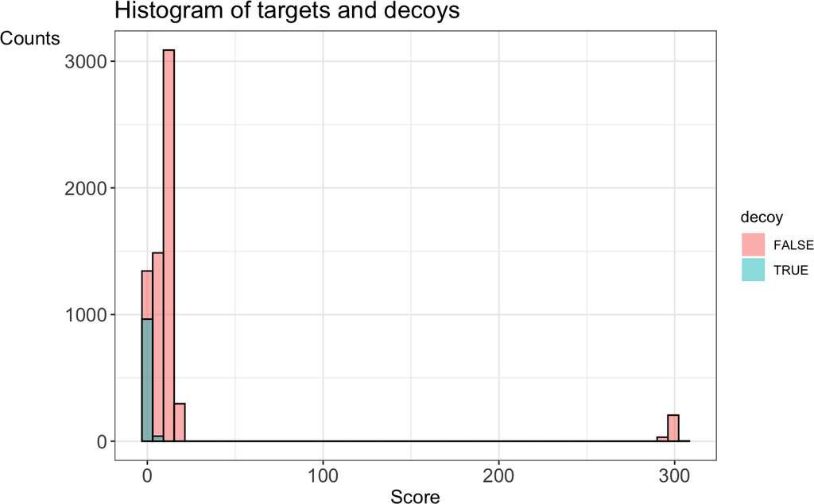

```r
      ggplot(data, aes(score, fill = decoy, col=I("black")))+ geom_histogram(alpha = 0.5, binwidth=binwidth, position = 'identity') +  labs(x = 'Score', y = 'Counts' ,title = 'Histogram of targets and decoys') +
  theme_bw() +
  theme(
    plot.title = element_text(size = rel(1.5)),
    axis.title = element_text(size = rel(1.2)),
    axis.text = element_text(size = rel(1.2)),
    axis.title.y = element_text(angle = 0))
```

### 2.1.3 PPplot of targets and decoys

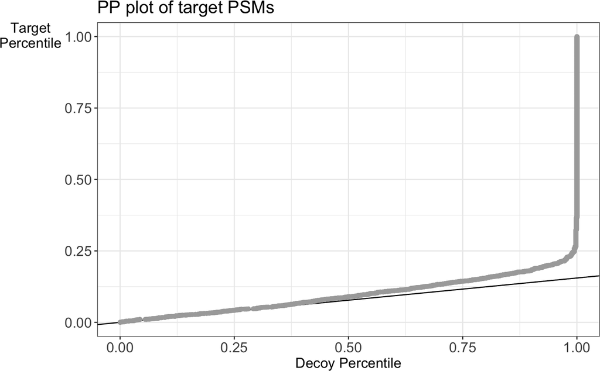

```r
library(dplyr)
pi0 <- sum(data$decoy)/sum(!data$decoy)
ppPlot <- ggplot()  +
geom_abline(slope = pi0,color = 'black') +
labs(x = 'Decoy Percentile', y = 'Target\nPercentile' ,title = 'PP plot of target PSMs') +
xlim(0,1) + ylim(0,1) +
theme_bw() +
theme(
   plot.title = element_text(size = rel(1.5)),
   axis.title = element_text(size = rel(1.2)),
   axis.text = element_text(size = rel(1.2)),
   axis.title.y = element_text(angle = 0))

x <- data$score[!data$decoy]
Ft <- ecdf(x)
Fd <- ecdf(data$score[data$decoy])
df <- data_frame(Fdp = Fd(x), Ftp = Ft(x))

ppPlot + geom_point(data = df,aes(Fdp,Ftp),color = 'dark grey')
```

## 2.2 Xtandem

### 2.2.1 Preprocess mzid data

```r
data <- dataFlat[,c("isdecoy","x!tandem:expect")]
names(data) <- c("decoy","score")
data <- na.exclude(data)
data$score <- -log10(as.double(data$score))
```

### 2.2.2 Histogram of targets and decoys

```r
library(ggplot2)

#We will use 50 breaks
nBreaks <- 50
binwidth <- diff(range(data$score))/nBreaks
print(binwidth)
```

```
## [1] 0.3622789
```

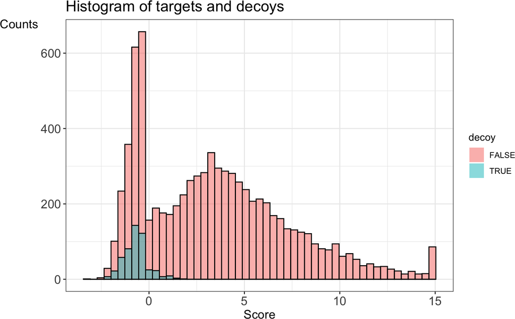

```r
      ggplot(data, aes(score, fill = decoy, col=I("black")))+ geom_histogram(alpha = 0.5, binwidth=binwidth, position = 'identity') +  labs(x = 'Score', y = 'Counts' ,title = 'Histogram of targets and decoys') +
  theme_bw() +
  theme(
    plot.title = element_text(size = rel(1.5)),
    axis.title = element_text(size = rel(1.2)),
    axis.text = element_text(size = rel(1.2)),
    axis.title.y = element_text(angle = 0))
```

### 2.2.3 PPplot of targets and decoys

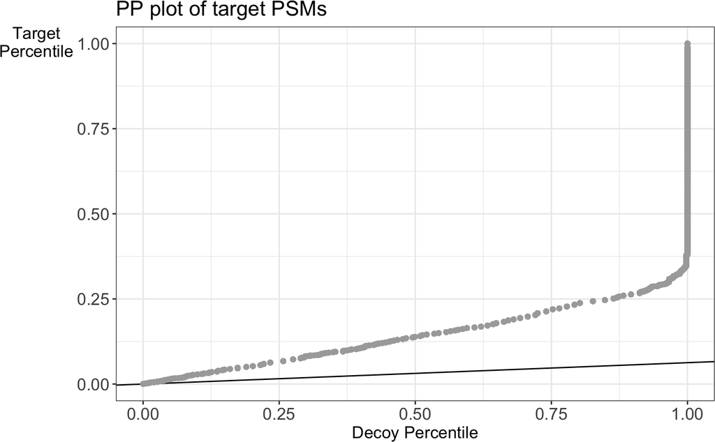

```r
library(dplyr)
pi0 <- sum(data$decoy)/sum(!data$decoy)
ppPlot <- ggplot()  +
geom_abline(slope = pi0,color = 'black') +
labs(x = 'Decoy Percentile', y = 'Target\nPercentile' ,title = 'PP plot of target PSMs') +
xlim(0,1) + ylim(0,1) +
theme_bw() +
theme(
   plot.title = element_text(size = rel(1.5)),
   axis.title = element_text(size = rel(1.2)),
   axis.text = element_text(size = rel(1.2)),
   axis.title.y = element_text(angle = 0))

x <- data$score[!data$decoy]
Ft <- ecdf(x)
Fd <- ecdf(data$score[data$decoy])
df <- data_frame(Fdp = Fd(x), Ftp = Ft(x))

ppPlot + geom_point(data = df,aes(Fdp,Ftp),color = 'dark grey')
```

Note, that the target decoy assumption is violated. We explained the reasons for this in the class.